# Data Preperation

Write a python program to merge data from each month into one CSV and read in updated datafram

```python
#importing pandas
import pandas as pd

#importing matplotlib
from matplotlib import pyplot as plt

import seaborn as sb
```

```python
#reading all the csv files and storing it in a dataframe
CSV_file_1 = pd.read_csv("CSV/Sales_January_2019.csv")
CSV_file_2 = pd.read_csv("CSV/Sales_February_2019.csv")
CSV_file_3 = pd.read_csv("CSV/Sales_March_2019.csv")
CSV_file_4 = pd.read_csv("CSV/Sales_April_2019.csv")
CSV_file_5 = pd.read_csv("CSV/Sales_May_2019.csv")
CSV_file_6 = pd.read_csv("CSV/Sales_June_2019.csv")
CSV_file_7 = pd.read_csv("CSV/Sales_July_2019.csv")
CSV_file_8 = pd.read_csv("CSV/Sales_August_2019.csv")
CSV_file_9 = pd.read_csv("CSV/Sales_September_2019.csv")
CSV_file_10 = pd.read_csv("CSV/Sales_October_2019.csv")
CSV_file_11 = pd.read_csv("CSV/Sales_November_2019.csv")
CSV_file_12 = pd.read_csv("CSV/Sales_December_2019.csv")

#Merging all CSV files into one merged CSV file using concat
Merged_CSV_file = pd.concat([CSV_file_1,CSV_file_2,CSV_file_3,CSV_file_4,CSV_file_5,CSV_file_6,CSV_file_7,
                             CSV_file_8,CSV_file_9,CSV_file_10,CSV_file_11,CSV_file_12])

#Storing merged data in one single csv file
Merged_CSV_file.to_csv ("merged_data.csv")
```

```python
#reading merged csv file and storing in dataframe
Dataframe = pd.read_csv("merged_data.csv")
Dataframe
```

|  | Unnamed: 0 | Order ID | Product | Quantity Ordered | Price Each | Order Date | Purchase Address |
| --- | --- | --- | --- | --- | --- | --- | --- |
| 0 | 0 | 141234.0 | iPhone | 1.0 | 700.00 | 1/22/2019 21:25 | 944 Walnut St, Boston, MA 02215 |
| 1 | 1 | 141235.0 | Lightning Charging Cable | 1.0 | 14.95 | 1/28/2019 14:15 | 185 Maple St, Portland, OR 97035 |
| 2 | 2 | 141236.0 | Wired Headphones | 2.0 | 11.99 | 1/17/2019 13:33 | 538 Adams St, San Francisco, CA 94016 |
| 3 | 3 | 141237.0 | 27in FHD Monitor | 1.0 | 149.99 | 1/5/2019 20:33 | 738 10th St, Los Angeles, CA 90001 |
| 4 | 4 | 141238.0 | Wired Headphones | 1.0 | 11.99 | 1/25/2019 11:59 | 387 10th St, Austin, TX 73301 |
| ... | ... | ... | ... | ... | ... | ... | ... |
| 186845 | 25112 | 319666.0 | Lightning Charging Cable | 1.0 | 14.95 | 12/11/2019 20:58 | 14 Madison St, San Francisco, CA 94016 |
| 186846 | 25113 | 319667.0 | AA Batteries (4-pack) | 2.0 | 3.84 | 12/1/2019 12:01 | 549 Willow St, Los Angeles, CA 90001 |
| 186847 | 25114 | 319668.0 | Vareebadd Phone | 1.0 | 400.00 | 12/9/2019 6:43 | 273 Wilson St, Seattle, WA 98101 |
| 186848 | 25115 | 319669.0 | Wired Headphones | 1.0 | 11.99 | 12/3/2019 10:39 | 778 River St, Dallas, TX 75001 |
| 186849 | 25116 | 319670.0 | Bose SoundSport Headphones | 1.0 | 99.99 | 12/21/2019 21:45 | 747 Chestnut St, Los Angeles, CA 90001 |

186850 rows × 7 columns

Write a python program to remove the NaN missing values from updated dataframe.

```python
#Checking if there is any Nan value
Dataframe.isnull().values.any()
```

```
True
```

```python
#checking nan values
Dataframe.isna().sum()
```

```
Unnamed: 0            0
Order ID            900
Product             900
Quantity Ordered    900
Price Each          900
Order Date          900
Purchase Address    900
dtype: int64
```

```python
Dataframe
```

|  | Unnamed: 0 | Order ID | Product | Quantity Ordered | Price Each | Order Date | Purchase Address |
| --- | --- | --- | --- | --- | --- | --- | --- |
| 0 | 0 | 141234.0 | iPhone | 1.0 | 700.00 | 1/22/2019 21:25 | 944 Walnut St, Boston, MA 02215 |
| 1 | 1 | 141235.0 | Lightning Charging Cable | 1.0 | 14.95 | 1/28/2019 14:15 | 185 Maple St, Portland, OR 97035 |
| 2 | 2 | 141236.0 | Wired Headphones | 2.0 | 11.99 | 1/17/2019 13:33 | 538 Adams St, San Francisco, CA 94016 |
| 3 | 3 | 141237.0 | 27in FHD Monitor | 1.0 | 149.99 | 1/5/2019 20:33 | 738 10th St, Los Angeles, CA 90001 |
| 4 | 4 | 141238.0 | Wired Headphones | 1.0 | 11.99 | 1/25/2019 11:59 | 387 10th St, Austin, TX 73301 |
| ... | ... | ... | ... | ... | ... | ... | ... |
| 186845 | 25112 | 319666.0 | Lightning Charging Cable | 1.0 | 14.95 | 12/11/2019 20:58 | 14 Madison St, San Francisco, CA 94016 |
| 186846 | 25113 | 319667.0 | AA Batteries (4-pack) | 2.0 | 3.84 | 12/1/2019 12:01 | 549 Willow St, Los Angeles, CA 90001 |
| 186847 | 25114 | 319668.0 | Vareebadd Phone | 1.0 | 400.00 | 12/9/2019 6:43 | 273 Wilson St, Seattle, WA 98101 |
| 186848 | 25115 | 319669.0 | Wired Headphones | 1.0 | 11.99 | 12/3/2019 10:39 | 778 River St, Dallas, TX 75001 |
| 186849 | 25116 | 319670.0 | Bose SoundSport Headphones | 1.0 | 99.99 | 12/21/2019 21:45 | 747 Chestnut St, Los Angeles, CA 90001 |

186850 rows × 7 columns

```python
#Dropping Nan values
Dataframe = Dataframe.drop(columns = 'Unnamed: 0')

Dataframe = Dataframe.dropna(axis = 0, how='all')
Dataframe.isna().sum()
```

```
Order ID            0
Product             0
Quantity Ordered    0
Price Each          0
Order Date          0
Purchase Address    0
dtype: int64
```

```python
#Checking Nan value after drropping it
Dataframe.isnull().values.any()
```

```
False
```

```python
Dataframe.isnull().sum().sum()
```

```
0
```

```python
Dataframe
```

|  | Order ID | Product | Quantity Ordered | Price Each | Order Date | Purchase Address |
| --- | --- | --- | --- | --- | --- | --- |
| 0 | 141234.0 | iPhone | 1.0 | 700.00 | 1/22/2019 21:25 | 944 Walnut St, Boston, MA 02215 |
| 1 | 141235.0 | Lightning Charging Cable | 1.0 | 14.95 | 1/28/2019 14:15 | 185 Maple St, Portland, OR 97035 |
| 2 | 141236.0 | Wired Headphones | 2.0 | 11.99 | 1/17/2019 13:33 | 538 Adams St, San Francisco, CA 94016 |
| 3 | 141237.0 | 27in FHD Monitor | 1.0 | 149.99 | 1/5/2019 20:33 | 738 10th St, Los Angeles, CA 90001 |
| 4 | 141238.0 | Wired Headphones | 1.0 | 11.99 | 1/25/2019 11:59 | 387 10th St, Austin, TX 73301 |
| ... | ... | ... | ... | ... | ... | ... |
| 186845 | 319666.0 | Lightning Charging Cable | 1.0 | 14.95 | 12/11/2019 20:58 | 14 Madison St, San Francisco, CA 94016 |
| 186846 | 319667.0 | AA Batteries (4-pack) | 2.0 | 3.84 | 12/1/2019 12:01 | 549 Willow St, Los Angeles, CA 90001 |
| 186847 | 319668.0 | Vareebadd Phone | 1.0 | 400.00 | 12/9/2019 6:43 | 273 Wilson St, Seattle, WA 98101 |
| 186848 | 319669.0 | Wired Headphones | 1.0 | 11.99 | 12/3/2019 10:39 | 778 River St, Dallas, TX 75001 |
| 186849 | 319670.0 | Bose SoundSport Headphones | 1.0 | 99.99 | 12/21/2019 21:45 | 747 Chestnut St, Los Angeles, CA 90001 |

185950 rows × 6 columns

Write a python program to convert Quantity Ordered and Price Each to numeric:

```python
Dataframe.info()
```

```
<class 'pandas.core.frame.DataFrame'>
Int64Index: 185950 entries, 0 to 186849
Data columns (total 6 columns):
 #   Column            Non-Null Count   Dtype
---  ------            --------------   -----
 0   Order ID          185950 non-null  float64
 1   Product           185950 non-null  object
 2   Quantity Ordered  185950 non-null  float64
 3   Price Each        185950 non-null  float64
 4   Order Date        185950 non-null  object
 5   Purchase Address  185950 non-null  object
dtypes: float64(3), object(3)
memory usage: 9.9+ MB
```

```python
#Channging the Data type to numeric
Dataframe['Quantity Ordered'] = pd.to_numeric(Dataframe['Quantity Ordered'])
Dataframe['Price Each'] = pd.to_numeric(Dataframe['Price Each'])
```

```python
Dataframe.info()
```

```
<class 'pandas.core.frame.DataFrame'>
Int64Index: 185950 entries, 0 to 186849
Data columns (total 6 columns):
 #   Column            Non-Null Count   Dtype
---  ------            --------------   -----
 0   Order ID          185950 non-null  float64
 1   Product           185950 non-null  object
 2   Quantity Ordered  185950 non-null  float64
 3   Price Each        185950 non-null  float64
 4   Order Date        185950 non-null  object
 5   Purchase Address  185950 non-null  object
dtypes: float64(3), object(3)
memory usage: 9.9+ MB
```

Create a new column named Month from Ordered Date of updated dataframe and convert it to integer as data type.

```python
#From orderdate extracting month and seperating it into column Month and monthname
Dataframe['Order Date'] = pd.to_datetime(Dataframe['Order Date'])
Dataframe['Month'] = Dataframe['Order Date'].dt.month.astype(int)
Dataframe['Month_name'] = Dataframe['Order Date'].dt.month_name()
```

```python
Dataframe
```

|  | Order ID | Product | Quantity Ordered | Price Each | Order Date | Purchase Address | Month | Month_name |
| --- | --- | --- | --- | --- | --- | --- | --- | --- |
| 0 | 141234.0 | iPhone | 1.0 | 700.00 | 2019-01-22 21:25:00 | 944 Walnut St, Boston, MA 02215 | 1 | January |
| 1 | 141235.0 | Lightning Charging Cable | 1.0 | 14.95 | 2019-01-28 14:15:00 | 185 Maple St, Portland, OR 97035 | 1 | January |
| 2 | 141236.0 | Wired Headphones | 2.0 | 11.99 | 2019-01-17 13:33:00 | 538 Adams St, San Francisco, CA 94016 | 1 | January |
| 3 | 141237.0 | 27in FHD Monitor | 1.0 | 149.99 | 2019-01-05 20:33:00 | 738 10th St, Los Angeles, CA 90001 | 1 | January |
| 4 | 141238.0 | Wired Headphones | 1.0 | 11.99 | 2019-01-25 11:59:00 | 387 10th St, Austin, TX 73301 | 1 | January |
| ... | ... | ... | ... | ... | ... | ... | ... | ... |
| 186845 | 319666.0 | Lightning Charging Cable | 1.0 | 14.95 | 2019-12-11 20:58:00 | 14 Madison St, San Francisco, CA 94016 | 12 | December |
| 186846 | 319667.0 | AA Batteries (4-pack) | 2.0 | 3.84 | 2019-12-01 12:01:00 | 549 Willow St, Los Angeles, CA 90001 | 12 | December |
| 186847 | 319668.0 | Vareebadd Phone | 1.0 | 400.00 | 2019-12-09 06:43:00 | 273 Wilson St, Seattle, WA 98101 | 12 | December |
| 186848 | 319669.0 | Wired Headphones | 1.0 | 11.99 | 2019-12-03 10:39:00 | 778 River St, Dallas, TX 75001 | 12 | December |
| 186849 | 319670.0 | Bose SoundSport Headphones | 1.0 | 99.99 | 2019-12-21 21:45:00 | 747 Chestnut St, Los Angeles, CA 90001 | 12 | December |

185950 rows × 8 columns

Create a new column named city from puchase address based on the value on updated dataframe

```python
# From column Purchase address, we are spliting the array and extracting the value of index 1
# and putting the value in new column City
Dataframe['City'] = Dataframe['Purchase Address'].str.split(',').str[1]
```

```python
Dataframe
```

|  | Order ID | Product | Quantity Ordered | Price Each | Order Date | Purchase Address | Month | Month_name | City |
| --- | --- | --- | --- | --- | --- | --- | --- | --- | --- |
| 0 | 141234.0 | iPhone | 1.0 | 700.00 | 2019-01-22 21:25:00 | 944 Walnut St, Boston, MA 02215 | 1 | January | Boston |
| 1 | 141235.0 | Lightning Charging Cable | 1.0 | 14.95 | 2019-01-28 14:15:00 | 185 Maple St, Portland, OR 97035 | 1 | January | Portland |
| 2 | 141236.0 | Wired Headphones | 2.0 | 11.99 | 2019-01-17 13:33:00 | 538 Adams St, San Francisco, CA 94016 | 1 | January | San Francisco |
| 3 | 141237.0 | 27in FHD Monitor | 1.0 | 149.99 | 2019-01-05 20:33:00 | 738 10th St, Los Angeles, CA 90001 | 1 | January | Los Angeles |
| 4 | 141238.0 | Wired Headphones | 1.0 | 11.99 | 2019-01-25 11:59:00 | 387 10th St, Austin, TX 73301 | 1 | January | Austin |
| ... | ... | ... | ... | ... | ... | ... | ... | ... | ... |
| 186845 | 319666.0 | Lightning Charging Cable | 1.0 | 14.95 | 2019-12-11 20:58:00 | 14 Madison St, San Francisco, CA 94016 | 12 | December | San Francisco |
| 186846 | 319667.0 | AA Batteries (4-pack) | 2.0 | 3.84 | 2019-12-01 12:01:00 | 549 Willow St, Los Angeles, CA 90001 | 12 | December | Los Angeles |
| 186847 | 319668.0 | Vareebadd Phone | 1.0 | 400.00 | 2019-12-09 06:43:00 | 273 Wilson St, Seattle, WA 98101 | 12 | December | Seattle |
| 186848 | 319669.0 | Wired Headphones | 1.0 | 11.99 | 2019-12-03 10:39:00 | 778 River St, Dallas, TX 75001 | 12 | December | Dallas |
| 186849 | 319670.0 | Bose SoundSport Headphones | 1.0 | 99.99 | 2019-12-21 21:45:00 | 747 Chestnut St, Los Angeles, CA 90001 | 12 | December | Los Angeles |

185950 rows × 9 columns

# Data Analysis

Write a Python program to show summary statistics of sum, mean,standard deviation, skewness, and kurtosis of any chosen variable.

```python
#calculating mean
Dataframe['Price Each'].mean()
```

```
184.39973476700638
```

```python
#calculating sum
Dataframe['Price Each'].sum()
```

```
34289130.68
```

```python
#calculating standard Deviation
Dataframe['Price Each'].std()
```

```
332.7313298840899
```

```python
#calculating Skewness
Dataframe['Price Each'].skew()
```

```
2.8721487292935266
```

```python
#calculating Kurtosis
Dataframe['Price Each'].kurtosis()
```

```
9.094568341148207
```

Write a Python program to calculate and show correlation of all variables.

```python
Dataframe
```

|  | Order ID | Product | Quantity Ordered | Price Each | Order Date | Purchase Address | Month | Month_name | City |
| --- | --- | --- | --- | --- | --- | --- | --- | --- | --- |
| 0 | 141234.0 | iPhone | 1.0 | 700.00 | 2019-01-22 21:25:00 | 944 Walnut St, Boston, MA 02215 | 1 | January | Boston |
| 1 | 141235.0 | Lightning Charging Cable | 1.0 | 14.95 | 2019-01-28 14:15:00 | 185 Maple St, Portland, OR 97035 | 1 | January | Portland |
| 2 | 141236.0 | Wired Headphones | 2.0 | 11.99 | 2019-01-17 13:33:00 | 538 Adams St, San Francisco, CA 94016 | 1 | January | San Francisco |
| 3 | 141237.0 | 27in FHD Monitor | 1.0 | 149.99 | 2019-01-05 20:33:00 | 738 10th St, Los Angeles, CA 90001 | 1 | January | Los Angeles |
| 4 | 141238.0 | Wired Headphones | 1.0 | 11.99 | 2019-01-25 11:59:00 | 387 10th St, Austin, TX 73301 | 1 | January | Austin |
| ... | ... | ... | ... | ... | ... | ... | ... | ... | ... |
| 186845 | 319666.0 | Lightning Charging Cable | 1.0 | 14.95 | 2019-12-11 20:58:00 | 14 Madison St, San Francisco, CA 94016 | 12 | December | San Francisco |
| 186846 | 319667.0 | AA Batteries (4-pack) | 2.0 | 3.84 | 2019-12-01 12:01:00 | 549 Willow St, Los Angeles, CA 90001 | 12 | December | Los Angeles |
| 186847 | 319668.0 | Vareebadd Phone | 1.0 | 400.00 | 2019-12-09 06:43:00 | 273 Wilson St, Seattle, WA 98101 | 12 | December | Seattle |
| 186848 | 319669.0 | Wired Headphones | 1.0 | 11.99 | 2019-12-03 10:39:00 | 778 River St, Dallas, TX 75001 | 12 | December | Dallas |
| 186849 | 319670.0 | Bose SoundSport Headphones | 1.0 | 99.99 | 2019-12-21 21:45:00 | 747 Chestnut St, Los Angeles, CA 90001 | 12 | December | Los Angeles |

185950 rows × 9 columns

```python
# finding correlation of the variables
Correlation = (Dataframe.corr())
Correlation
```

|  | Order ID | Quantity Ordered | Price Each | Month |
| --- | --- | --- | --- | --- |
| Order ID | 1.000000 | 0.000702 | -0.002857 | 0.993063 |
| Quantity Ordered | 0.000702 | 1.000000 | -0.148272 | 0.000791 |
| Price Each | -0.002857 | -0.148272 | 1.000000 | -0.003375 |
| Month | 0.993063 | 0.000791 | -0.003375 | 1.000000 |

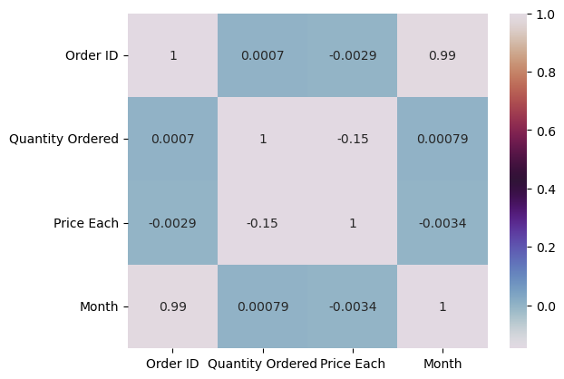

```python
# using seaborn library to create heatmap
dataplot = sb.heatmap(Dataframe.corr(), cmap="twilight", annot=True)
```

# Data Exploration

Which Month has the best sales? and how much was the earning in that month? Make a bar graph of sales as well.

```python
#Since there are multiple dats with same month name we are usinmg unique keyword to get only one month name
unique_months = pd.unique(Dataframe['Month_name'])
unique_months.sort()

unique_months
```

```
array(['April', 'August', 'December', 'February', 'January', 'July',
       'June', 'March', 'May', 'November', 'October', 'September'],
      dtype=object)
```

```python
# Creating new column named total sum in dataframe and inseting total sum acquired by multiplying quantity and price
Dataframe['Total_sum'] = Dataframe['Quantity Ordered'] * Dataframe['Price Each']

# CREATING a variable nameed Total_sum_of_month and storing the total sum of month acquired by grouping monthname with
# total sum
Total_sum_of_month = Dataframe.groupby('Month_name')['Total_sum'].sum()
```

```python
#Creating new Dataframe named frame
frame = pd.DataFrame()

#Adding duplicate_months adn Total_sum_of_month.values into the dataframe "frame"
frame['Month_name']= unique_months
frame['sum'] = Total_sum_of_month.values

frame[['Month_name', 'sum']]
```

|  | Month_name | sum |
| --- | --- | --- |
| 0 | April | 3390670.24 |
| 1 | August | 2244467.88 |
| 2 | December | 4613443.34 |
| 3 | February | 2202022.42 |
| 4 | January | 1822256.73 |
| 5 | July | 2647775.76 |
| 6 | June | 2577802.26 |
| 7 | March | 2807100.38 |
| 8 | May | 3152606.75 |
| 9 | November | 3199603.20 |
| 10 | October | 3736726.88 |
| 11 | September | 2097560.13 |

```python
#Finding the month with highest sales
frame[Total_sum_of_month.index == Total_sum_of_month.idxmax()]
```

|  | Month_name | sum |
| --- | --- | --- |
| 2 | December | 4613443.34 |

```python
#Finding the month with lowest sales
frame[Total_sum_of_month.index == Total_sum_of_month.idxmin()]
```

|  | Month_name | sum |
| --- | --- | --- |
| 4 | January | 1822256.73 |

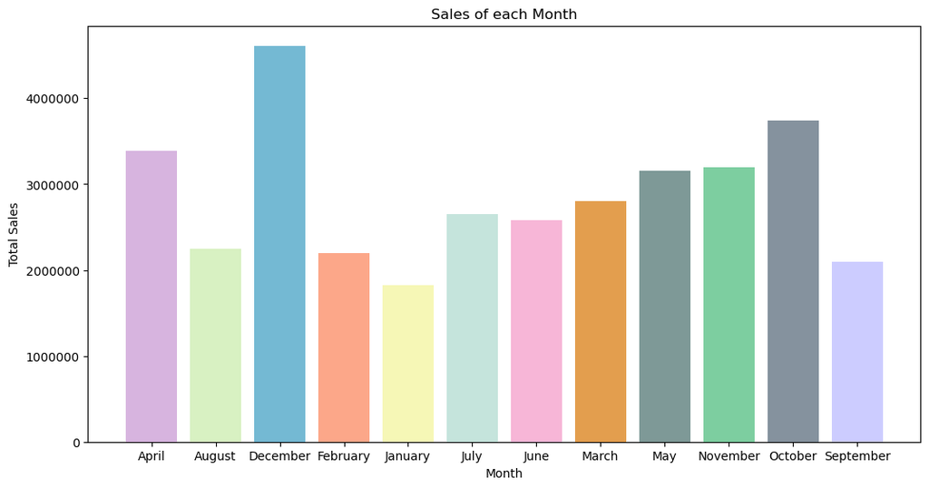

```python
#Creating a bar graph with different colors
fig= plt.figure()
axes = fig.add_axes([0.1,0.1,1.5,1])
color = ['#D7B4DF', '#D8F1C2', '#74B9D3', '#FCA789', '#F6F7B6', '#c5e4dc', '#F7B6D7','#E39E4E', '#7E9997', '#7DCEA0',
         '#85929E', '#CCCCFF']
plt.ticklabel_format(style='plain')

# Adding the columns into the bar graph and giving labels
axes.bar(unique_months,Total_sum_of_month, width=0.8, color = color)

#Naming labels and setting title
axes.set_xlabel("Month")
axes.set_ylabel("Total Sales")
axes.set_title("Sales of each Month")

plt.show()
```

Which city has sold the highest product?

```python
Dataframe
```

|  | Order ID | Product | Quantity Ordered | Price Each | Order Date | Purchase Address | Month | Month_name | City | Total_sum |
| --- | --- | --- | --- | --- | --- | --- | --- | --- | --- | --- |
| 0 | 141234.0 | iPhone | 1.0 | 700.00 | 2019-01-22 21:25:00 | 944 Walnut St, Boston, MA 02215 | 1 | January | Boston | 700.00 |
| 1 | 141235.0 | Lightning Charging Cable | 1.0 | 14.95 | 2019-01-28 14:15:00 | 185 Maple St, Portland, OR 97035 | 1 | January | Portland | 14.95 |
| 2 | 141236.0 | Wired Headphones | 2.0 | 11.99 | 2019-01-17 13:33:00 | 538 Adams St, San Francisco, CA 94016 | 1 | January | San Francisco | 23.98 |
| 3 | 141237.0 | 27in FHD Monitor | 1.0 | 149.99 | 2019-01-05 20:33:00 | 738 10th St, Los Angeles, CA 90001 | 1 | January | Los Angeles | 149.99 |
| 4 | 141238.0 | Wired Headphones | 1.0 | 11.99 | 2019-01-25 11:59:00 | 387 10th St, Austin, TX 73301 | 1 | January | Austin | 11.99 |
| ... | ... | ... | ... | ... | ... | ... | ... | ... | ... | ... |
| 186845 | 319666.0 | Lightning Charging Cable | 1.0 | 14.95 | 2019-12-11 20:58:00 | 14 Madison St, San Francisco, CA 94016 | 12 | December | San Francisco | 14.95 |
| 186846 | 319667.0 | AA Batteries (4-pack) | 2.0 | 3.84 | 2019-12-01 12:01:00 | 549 Willow St, Los Angeles, CA 90001 | 12 | December | Los Angeles | 7.68 |
| 186847 | 319668.0 | Vareebadd Phone | 1.0 | 400.00 | 2019-12-09 06:43:00 | 273 Wilson St, Seattle, WA 98101 | 12 | December | Seattle | 400.00 |
| 186848 | 319669.0 | Wired Headphones | 1.0 | 11.99 | 2019-12-03 10:39:00 | 778 River St, Dallas, TX 75001 | 12 | December | Dallas | 11.99 |
| 186849 | 319670.0 | Bose SoundSport Headphones | 1.0 | 99.99 | 2019-12-21 21:45:00 | 747 Chestnut St, Los Angeles, CA 90001 | 12 | December | Los Angeles | 99.99 |

185950 rows × 10 columns

```python
#Using group by to find out the total quantites ordered from a city.
Total_sale = Dataframe.groupby(Dataframe.City)['Quantity Ordered'].sum()
```

```python
Total_sale
```

```
City
 Atlanta          16602.0
 Austin           11153.0
 Boston           22528.0
 Dallas           16730.0
 Los Angeles      33289.0
 New York City    27932.0
 Portland         14053.0
 San Francisco    50239.0
 Seattle          16553.0
Name: Quantity Ordered, dtype: float64
```

```python
#Finding the city with highest sales using idxmax
Total_sale[Total_sale.index == Total_sale.idxmax()]
```

```
City
 San Francisco    50239.0
Name: Quantity Ordered, dtype: float64
```

Which product was sold the most in overall? Illustrate it through bar graph.

```python
#Using group by to find out the total sold quantites of a product.
Total_product_sales = Dataframe.groupby(Dataframe.Product)['Quantity Ordered'].sum()
Total_product_sales
```

```
Product
20in Monitor                   4129.0
27in 4K Gaming Monitor         6244.0
27in FHD Monitor               7550.0
34in Ultrawide Monitor         6199.0
AA Batteries (4-pack)         27635.0
AAA Batteries (4-pack)        31017.0
Apple Airpods Headphones      15661.0
Bose SoundSport Headphones    13457.0
Flatscreen TV                  4819.0
Google Phone                   5532.0
LG Dryer                        646.0
LG Washing Machine              666.0
Lightning Charging Cable      23217.0
Macbook Pro Laptop             4728.0
ThinkPad Laptop                4130.0
USB-C Charging Cable          23975.0
Vareebadd Phone                2068.0
Wired Headphones              20557.0
iPhone                         6849.0
Name: Quantity Ordered, dtype: float64
```

```python
#Finding the product with highest sales using idxmax
Total_product_sales[Total_product_sales.index == Total_product_sales.idxmax()]
```

```
Product
AAA Batteries (4-pack)    31017.0
Name: Quantity Ordered, dtype: float64
```

```python
#Dropping repeatitve Products using the funtion unique()
unique_products= Dataframe['Product'].unique()
unique_products.sort()
unique_products
```

```
array(['20in Monitor', '27in 4K Gaming Monitor', '27in FHD Monitor',
       '34in Ultrawide Monitor', 'AA Batteries (4-pack)',
       'AAA Batteries (4-pack)', 'Apple Airpods Headphones',
       'Bose SoundSport Headphones', 'Flatscreen TV', 'Google Phone',
       'LG Dryer', 'LG Washing Machine', 'Lightning Charging Cable',
       'Macbook Pro Laptop', 'ThinkPad Laptop', 'USB-C Charging Cable',
       'Vareebadd Phone', 'Wired Headphones', 'iPhone'], dtype=object)
```

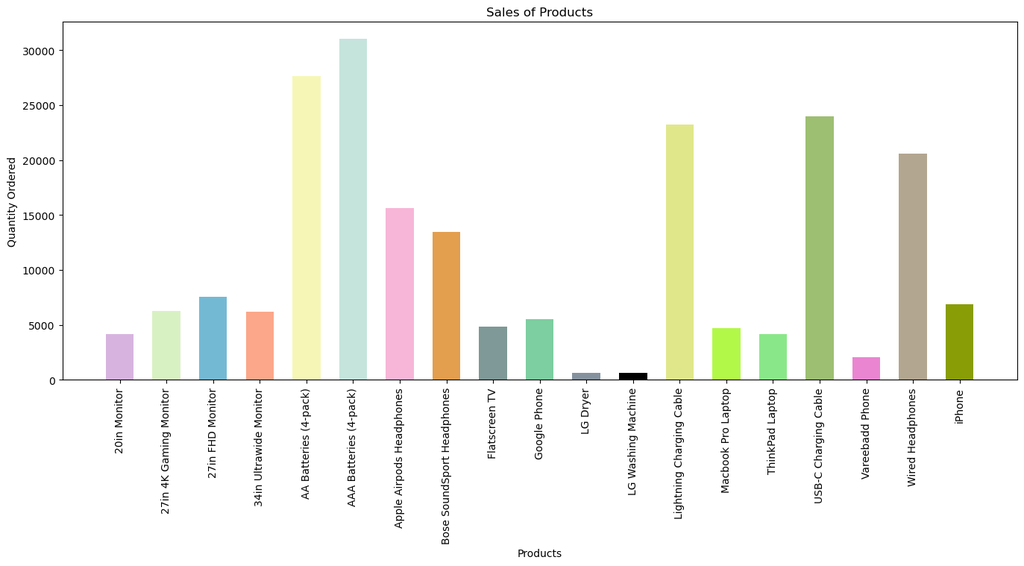

```python
#Creating a bar graph with different colors
fig= plt.figure()
axes = fig.add_axes([0.1,0.1,2,1])

colors = ['#D7B4DF', '#D8F1C2', '#74B9D3', '#FCA789', '#F6F7B6', '#c5e4dc', '#F7B6D7','#E39E4E', '#7E9997', '#7DCEA0',
         '#85929E', '#000000','#E0E78B','#B2F849','#8AE789','#9DBF72','#EA85D1','#B3A690','#899D06']

# Adding the columns into the bar graph and giving labels
axes.bar(unique_products,Total_product_sales, width=0.6, color = colors)

# turning the vlaues in x label 90 degree
plt.xticks(rotation = 90)

#Setting label name and title name
axes.set_ylabel("Quantity Ordered")
axes.set_xlabel("Products")
axes.set_title("Sales of Products")
```

```python
Dataframe
```

|  | Order ID | Product | Quantity Ordered | Price Each | Order Date | Purchase Address | Month | Month_name | City | Total_sum |
| --- | --- | --- | --- | --- | --- | --- | --- | --- | --- | --- |
| 0 | 141234.0 | iPhone | 1.0 | 700.00 | 2019-01-22 21:25:00 | 944 Walnut St, Boston, MA 02215 | 1 | January | Boston | 700.00 |
| 1 | 141235.0 | Lightning Charging Cable | 1.0 | 14.95 | 2019-01-28 14:15:00 | 185 Maple St, Portland, OR 97035 | 1 | January | Portland | 14.95 |
| 2 | 141236.0 | Wired Headphones | 2.0 | 11.99 | 2019-01-17 13:33:00 | 538 Adams St, San Francisco, CA 94016 | 1 | January | San Francisco | 23.98 |
| 3 | 141237.0 | 27in FHD Monitor | 1.0 | 149.99 | 2019-01-05 20:33:00 | 738 10th St, Los Angeles, CA 90001 | 1 | January | Los Angeles | 149.99 |
| 4 | 141238.0 | Wired Headphones | 1.0 | 11.99 | 2019-01-25 11:59:00 | 387 10th St, Austin, TX 73301 | 1 | January | Austin | 11.99 |
| ... | ... | ... | ... | ... | ... | ... | ... | ... | ... | ... |
| 186845 | 319666.0 | Lightning Charging Cable | 1.0 | 14.95 | 2019-12-11 20:58:00 | 14 Madison St, San Francisco, CA 94016 | 12 | December | San Francisco | 14.95 |
| 186846 | 319667.0 | AA Batteries (4-pack) | 2.0 | 3.84 | 2019-12-01 12:01:00 | 549 Willow St, Los Angeles, CA 90001 | 12 | December | Los Angeles | 7.68 |
| 186847 | 319668.0 | Vareebadd Phone | 1.0 | 400.00 | 2019-12-09 06:43:00 | 273 Wilson St, Seattle, WA 98101 | 12 | December | Seattle | 400.00 |
| 186848 | 319669.0 | Wired Headphones | 1.0 | 11.99 | 2019-12-03 10:39:00 | 778 River St, Dallas, TX 75001 | 12 | December | Dallas | 11.99 |
| 186849 | 319670.0 | Bose SoundSport Headphones | 1.0 | 99.99 | 2019-12-21 21:45:00 | 747 Chestnut St, Los Angeles, CA 90001 | 12 | December | Los Angeles | 99.99 |

185950 rows × 10 columns

Write a Python program to show histogram plot of any chosen variables. Use proper labels in the graph.

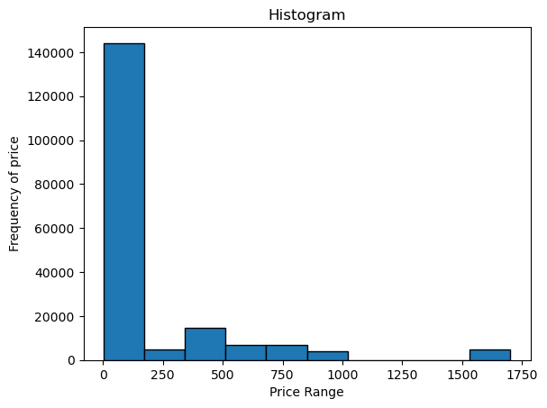

```python
# using .hist function to create the histogram
fig, axes = plt.subplots()

plt.hist(Dataframe['Price Each'], edgecolor = 'black', bins = 10)
axes.set_xlabel("Price Range")
axes.set_ylabel('Frequency of price')
axes.set_title("Histogram")
plt.show()
```